# Regression methods

bayesics Package Version 2.0.0

# Linear regression with `lm_b`

## Statistical Model

Linear regression is the bread and butter of the practicing statistician. Mathematically, the model is given by
$$\begin{aligned}
y & = X\beta + \epsilon, \\
\epsilon & \sim N(0,\sigma^2 I).
\end{aligned}
\tag{1}$$

While an improper prior of the form
$$\pi(\beta,\sigma^2) \propto \frac{1}{\sigma^2}$$
can be used, it is recommended to use a proper prior. In `bayesics` we implement a normal-inverse gamma prior:
$$\begin{aligned}
\beta|\sigma^2 & \sim N(\mu,\sigma^2 V^{-1}),\\
\sigma^2 & \sim \Gamma^{-1}(a/2,b/2).
\end{aligned}$$

The resulting posterior (for both proper and improper priors) is of the same form:
$$\begin{aligned}
\beta|y,\sigma^2 & \sim N(\tilde\mu,\sigma^2 \widetilde{V}^{-1}),\\
\sigma^2|y & \sim \Gamma^{-1}(\tilde a/2,\tilde b/2).
\end{aligned}$$

In `lm_b` the mapping of parameters to arguments is given by:

| Prior Parameters Parameter $\mu$ | Prior Parameters bayesics argument `prior_beta_mean` |
| --- | --- |
| $V$ | `prior_beta_precision` |
| $a$ | `prior_var_shape` |
| $b$ | `prior_var_rate` |
| Posterior parameters | Posterior parameters |
| $\tilde\mu$ | `object$posterior_parameters$mu_tilde` |
| $\widetilde V$ | `object$posterior_parameters$V_tilde` |
| $\tilde a$ | `object$posterior_parameters$a_tilde` |
| $\tilde b$ | `object$posterior_parameters$b_tilde` |

## Default priors

### $\beta$

The other built-in prior is if `prior="conjugate"`. The prior precision matrix $V$ is set to be a diagonal matrix, with notions from standardized regression motivating the diagonal elements. In standardized regression, we consider the following:
$$\begin{aligned}
y_i^*& = \frac{y_i-\bar y}{s_y}, \\
X_{ij}^*& = \frac{X_{ij}-\bar X_j}{s_j}, \\
\end{aligned}$$
Note that there is a simple 1-1 transformation to get from the standardized regression coefficients ($\beta^*$) back to the coefficients on the original scale:
$$\begin{aligned}
\beta_j &= \frac{s_y}{s_j}\beta_j^* \\
\beta_0 &= \bar y - \beta_1\bar X_1 - \ldots - \beta_{p-1}\bar X_{p-1}
\end{aligned}$$
Here is the underlying principle to set the prior hyperparameters: *If we feel 95% sure that a standard deviation change in* $X_{ij}$ *would not lead to more than a 5 SD increase in* $y$, *i.e.*, $1.96 \cdot SD(\beta_j^*) \approx 2\cdot SD(\beta_j^*) = 5$, then we could set
$$\begin{aligned}
\beta^*_j &\sim N(0,25/4), \\
\Rightarrow \beta_{-1} & \sim N\left(0,\frac{25}{4} \text{Diag}\left(\frac{s^2_y}{s^2_j}\right)\right)
\end{aligned}$$
where $s_y$ is the standard deviation of $y$, $s_j$ is the standard deviation of the $j^{th}$ covariate, $\beta_{-1}$ is the vector of regression coefficients sans the intercept. We can complete $V$ by setting a flat prior on the intercept such that the prior variance is $\frac{25}{4}s_y^2$.

### $\sigma^2$

By default, the values of $a$ and $b$ are set to be small (0.001) in order to provide a very flat prior on $\sigma^2$. However, we can find a better prior using the `bayesics` function `find_invgamma_parms()`. As a running example, we’ll look at the air quality dataset:

```r
library(dplyr)
library(bayesics)
data("airquality",package = "datasets")

aq =
  airquality |>
  mutate(
    # Use log(ozone) as response variable
    log_ozone = log(Ozone),
    # Compute the day of the year
    year_day =
      cumsum(c(0,31,28,31,30,31,30,31,31,30,31,30))[Month] + Day,
    # Turn month into a factor variable
    Month = factor(Month)) |>
  na.omit()
```

A reasonable approach to building a good prior on $\sigma^2$ via a peak at the data would be to look at the sample variance of the response variable, and then build a prior around that. If a priori we are 80% sure the covariates will explain between 10% and 90% of the variation in y, then the prior on $\sigma^2$ ought to have 0.8 of its probability mass between $0.1s^2_y$ and $0.9s^2_y$.

```r
s2_y = var(aq$log_ozone)
a_and_b =
  find_invgamma_parms(lower_quantile = 0.1 * s2_y,
                      upper_quantile = 0.9 * s2_y,
                      probability = 0.8)
a_and_b
```

```
#>     shape      rate
#> 3.3939804 0.5144621
```

```r
# or equivalently:
find_invgamma_parms(response_variance = s2_y,
                    lower_R2 = 0.1,
                    upper_R2 = 0.9,
                    probability = 0.8,
                    plot = FALSE)
```

```
#>     shape      rate
#> 3.3939804 0.5144621
```

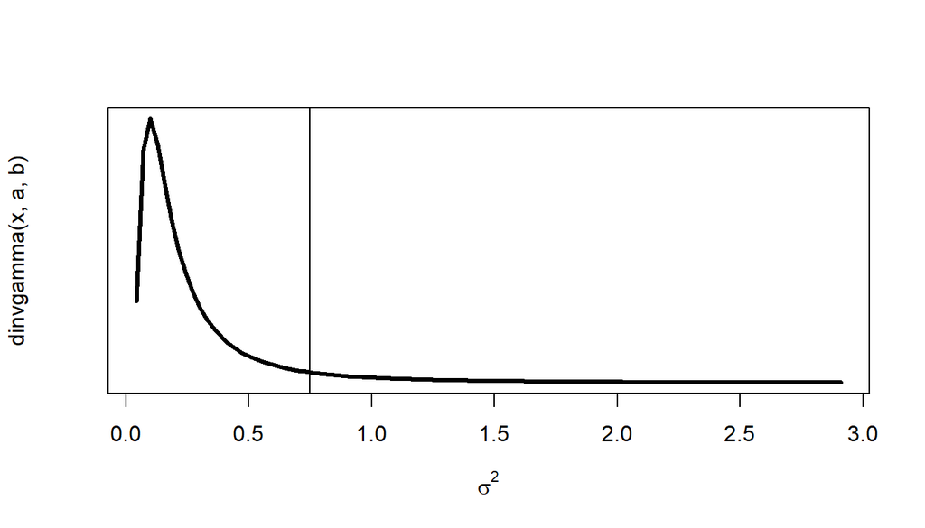

```r
abline(v = s2_y)
```

```r
# Check, since a solution is not at all guaranteed to exist:
extraDistr::pinvgamma(0.1 * s2_y,
                      0.5 * a_and_b[1],
                      0.5 * a_and_b[2])
```

```
#> [1] 0.1000865
```

```r
extraDistr::pinvgamma(0.9 * s2_y,
                      0.5 * a_and_b[1],
                      0.5 * a_and_b[2],
                      lower.tail = FALSE)
```

```
#> [1] 0.09984046
```

```r
library(dplyr)
library(splines)
library(bayesics)
data("airquality",package = "datasets")
aq =
  airquality |>
  mutate(year_day =
           cumsum(c(0,31,28,31,30,31,30,31,31,30,31,30))[Month] + Day,
         Month = factor(Month)) |>
  na.omit()

fit_1 =
  lm_b(Ozone ~ Solar.R + Wind + Temp + Month,
       data = aq)
plot(fit_1,
     type = "dx")

fit_2 =
  lm_b(log(Ozone) ~ Solar.R + Wind + Temp + ns(year_day,df = 5),
       data = aq)
plot(fit_2,
     type = "dx")

fit_3 =
  lm_b(log(Ozone) ~ Solar.R + Wind * Temp + Month,
       data = aq)
plot(fit_3,
     type = "dx")
plot(fit_3,
     type = c("pdp"))
plot(fit_3)

fit_4 =
  lm_b(log(Ozone) ~ Solar.R + I(Solar.R^2) + Wind + Temp,
       data = aq)
```

[output not shown]

Zellner, Arnold. 1986. “On Assessing Prior Distributions and Bayesian Regression Analysis with $g$-Prior Distributions.” In *Bayesian Inference and Decision Techniques: Essays in Honor of Bruno de Finetti*, edited by Prem K. Goel and Arnold Zellner, 6:233–43. Studies in Bayesian Econometrics and Statistics. Amsterdam: North-Holland Publishing Co.